# Machine Learning Project : Humain Activity Recognition

Nicolas

14 novembre 2016

## Summary

The above study consist into the selection of a machine learning model for the classification of observations related to Weight Lifting Exercise. Data set provided has been splitted in a train and test sets. Train set model has been developped and cross validated using random forest algorithm and XgBoost, then selected based on the accurary on the test set.

Although Random Forest shown good result with a >99% accuracy, XgBoost has been selected considering a slightly better accurary with a smaller calculation time. Several features has reveled themselves to be important for classification.

Finaly, provided validation set of 20 observations has been classified using the trained model.

## Processing

Using devices such as Jawbone Up, Nike FuelBand, and Fitbit it is now possible to collect a large amount of data about personal activity relatively inexpensively. In this project, our goal has been to use data from accelerometers on the belt, forearm, arm, and dumbell of 6 participants. They were asked to perform barbell lifts correctly and incorrectly in 5 different ways.data frm http://groupware.les.inf.puc-rio.br/har

```r
download.file("https://d396qusza40orc.cloudfront.net/predmachlearn/pml-training.csv",
              "training.csv")
download.file("https://d396qusza40orc.cloudfront.net/predmachlearn/pml-testing.csv",
              "test.csv")
training <- read.csv("training.csv",stringsAsFactors = FALSE)
```

From the initial package of data, we first will subset the elements to keep only variables, without NA (only non numerical value being the name of participant and response column). In addition, we removed any elements related to the timestamp, as the search model is timeset independant [considering that the expected prediction will be done on 20 time idependant observation].

```r
library(corrplot)
sub.training <- training %>% select_if(is.numeric) %>%
        select_if(function(col)all(!is.na(col))) %>%
        dplyr::select(-raw_timestamp_part_1,-raw_timestamp_part_2,-num_window,-X)
```

Correlation between features, as shown in the following figures, is in vast majority in good chape for later analysis, with most of the feature being square.

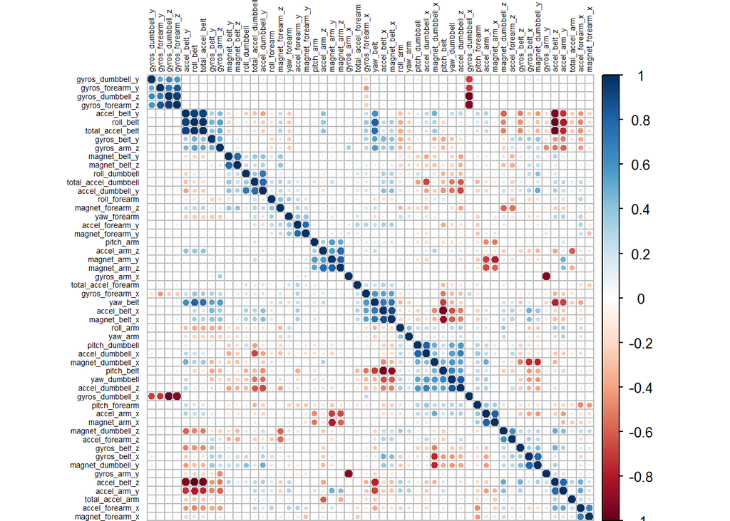

```r
cor.sub.training <- cor(sub.training)
corrplot(cor.sub.training, order = "hclust", tl.col="black", tl.cex=.45)
```

```r
HighCorr <- findCorrelation(cor.sub.training, 0.85)
sub.filtered.training <- sub.training[,-HighCorr]
sub.filtered.training <- sub.training
```

## Model Training

We trained two models for classificiation, with multiclass (5 expected) :

- A random forest model
- A XgBoost model

In addition, both are crossvalidated using a 4 fold resample.

```r
trainIndex <- createDataPartition(training$classe,p=.8,list=F,times=1)
train.set <- sub.filtered.training[trainIndex,]
test.set <- sub.filtered.training[-trainIndex,]

train.labels <- as.factor(training$classe[trainIndex])
test.labels <- as.factor(training$classe[-trainIndex])

ctrl <- trainControl(method = "cv", number = 4, returnResamp = "all", search = "random",classProbs = T)

ranger.fit <- train(y=train.labels,x=train.set, method = "ranger", trControl = ctrl, metric = "Accuracy", importance = "permutation", verbose=F)
train.xgb <- xgb.DMatrix(data.matrix(train.set), label=(as.numeric(train.labels)-1), missing=NA)

params.xgb <- list(
        "eta"=0.1,
        "max_depth"=15,
        "subsamble"=0.8,
        "colsample_bytree"=0.8,
        "eval_metric"="merror",
        "objective"="multi:softprob",
        "num_class"=5,
        "nthread"=4,
        "min_child_weigth"=12
)

xgb.fit.cv <- xgb.cv(param=params.xgb, data=train.xgb, nfold=4, nrounds=300, prediction=TRUE, verbose=F)

best.rank <- which.min(xgb.fit.cv$dt[, test.merror.mean])

xgb.fit <- xgboost(param=params.xgb,data = train.xgb,nrounds=best.rank, verbose=F)
```

## model selection

Here under confugion matrix shows a sligth advantage for the XgBoost algoritm. Accuraty on the test set of both models are very good, and we expect a good result on the validation set of 20 observations.

As a consequence, XGboost models is kept as better solution for classification of this example.

```r
pred.ranger <- predict(ranger.fit,newdata=test.set)
confusionMatrix(test.labels,pred.ranger)
```

```
## Confusion Matrix and Statistics
##
##           Reference
## Prediction    A    B    C    D    E
##          A 1114    2    0    0    0
##          B    6  752    1    0    0
##          C    0    4  675    4    1
##          D    0    2    4  636    1
##          E    0    2    0    0  719
##
## Overall Statistics
##
##                Accuracy : 0.9931
##                  95% CI : (0.99, 0.9955)
##     No Information Rate : 0.2855
##     P-Value [Acc > NIR] : < 2.2e-16
##
##                   Kappa : 0.9913
##  Mcnemar's Test P-Value : NA
##
## Statistics by Class:
##
##                      Class: A Class: B Class: C Class: D Class: E
## Sensitivity            0.9946   0.9869   0.9926   0.9938   0.9972
## Specificity            0.9993   0.9978   0.9972   0.9979   0.9994
## Pos Pred Value         0.9982   0.9908   0.9868   0.9891   0.9972
## Neg Pred Value         0.9979   0.9968   0.9985   0.9988   0.9994
## Prevalence             0.2855   0.1942   0.1733   0.1631   0.1838
## Detection Rate         0.2840   0.1917   0.1721   0.1621   0.1833
## Detection Prevalence   0.2845   0.1935   0.1744   0.1639   0.1838
## Balanced Accuracy      0.9970   0.9923   0.9949   0.9958   0.9983
```

```r
test.xgb <- xgb.DMatrix(data.matrix(test.set), label=(as.numeric(test.labels)-1), missing=NA)
pred.xgb <- predict(xgb.fit,newdata=test.xgb)
pred.xgb <- matrix(pred.xgb,nrow=length(pred.xgb)/5,ncol=5,byrow=T)
confusionMatrix((test.labels),c("A","B","C","D","E")[max.col(pred.xgb,"last")])
```

```
## Confusion Matrix and Statistics
##
##           Reference
## Prediction    A    B    C    D    E
##          A 1116    0    0    0    0
##          B    1  758    0    0    0
##          C    0    5  678    1    0
##          D    0    0    2  641    0
##          E    0    0    0    0  721
##
## Overall Statistics
##
##                Accuracy : 0.9977
##                  95% CI : (0.9956, 0.999)
##     No Information Rate : 0.2847
##     P-Value [Acc > NIR] : < 2.2e-16
##
##                   Kappa : 0.9971
##  Mcnemar's Test P-Value : NA
##
## Statistics by Class:
##
##                      Class: A Class: B Class: C Class: D Class: E
## Sensitivity            0.9991   0.9934   0.9971   0.9984   1.0000
## Specificity            1.0000   0.9997   0.9981   0.9994   1.0000
## Pos Pred Value         1.0000   0.9987   0.9912   0.9969   1.0000
## Neg Pred Value         0.9996   0.9984   0.9994   0.9997   1.0000
## Prevalence             0.2847   0.1945   0.1733   0.1637   0.1838
## Detection Rate         0.2845   0.1932   0.1728   0.1634   0.1838
## Detection Prevalence   0.2845   0.1935   0.1744   0.1639   0.1838
## Balanced Accuracy      0.9996   0.9966   0.9976   0.9989   1.0000
```

## Result and Validation Set Prediction

XgBoost selected model has sort the feature by importance for the classification of the observations. Here under table list the 10 feature that are more impacting for the classification.

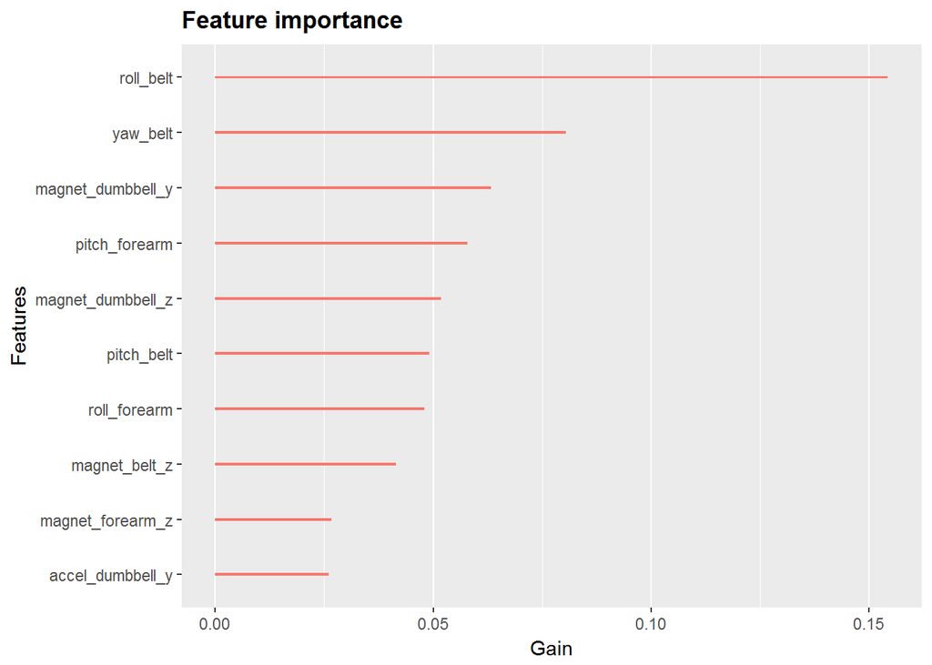

```r
feat_imp <- xgb.importance(names(train.set),model=xgb.fit)
xgb.plot.importance(feat_imp[1:10,],1)+theme(legend.position = "none")
```

Provided set of 20 observations are then classified. Result is shown here under.

```r
validation <- read.csv("test.csv",stringsAsFactors = FALSE)
t_validation <- validation[,names(data.frame(sub.filtered.training))]
pred.xgb <- predict(xgb.fit,newdata=data.matrix(t_validation))
pred.xgb <- matrix(pred.xgb,nrow=length(pred.xgb)/5,ncol=5,byrow=T)
validation.prediction <- c("A","B","C","D","E")[max.col(pred.xgb,"last")]
validation.prediction
```

```
##  [1] "B" "A" "B" "A" "A" "E" "D" "B" "A" "A" "B" "C" "B" "A" "E" "E" "A"
## [18] "B" "B" "B"
```